# 5 Tidy data

## 5.1 Introduction

A dataset is a collection of values, usually numeric, but often also characters, boolean or data/time values (see e.g. Wickham (2014)). A variable measures the same underlying attributes across the observational units. The underlying attribute could be e.g. price, quantity, weight, length, frequency, time, GDP, unemployment, consumer satisfaction, age, religion, size, speed, depth, … . Examples of observational units are individuals, households, firms, countries, regions, firms, departments, products, forests, oceans, transactions, … . A variable measures for all households, firms, products, … in the dataset the same attribute (e.g. income, price, quantity, ….). A dataset usually includes more than one variable. One observation includes all variables that are measured for the same observational unit. For instance, with people, an observations includes the person as well as variables such as income, age, religion, employment status, experience, educational attainment, … . Values belong to both variables as well as observations. For instance, in a dataset with macro-economic data on countries, the value $600b for GDP belongs to both a variable (GDP) as well as an observation: the country whose GDP is $600b.

Datasets are often presented in different ways. For instance, consider Table 5.1 and Table 5.2 taken from Wickham (2014). These tables show the effect of two treatments (A and B) on 3 people (John Smith, Jane Doe and Mary Jones). In these tables, the variables are the treatment, the observational units the individuals and the values the results.

The first way to present the data includes the variables in the columns and the observational units in the rows and is shown in Table 5.1. One observation then equals all results for both treatment A and B for each individual.

Table 5.1: A typical presentations of a dataset

|  | Treatment A | Treatment B |
| --- | --- | --- |
| John Smith | - | 2 |
| Jane Doe | 16 | 11 |
| Mary Johnson | 3 | 1 |

Here, you see that John Smith didn’t undergo treatment A or that the data for that individual and for treatment A are missing. For the two other persons, we have a value for both treatment A and treatment B. Presenting the data in this way, invites people to compare both treatments: reading from left to right; Jane Doe’s results for A were better (of worse, depending on the exact definition of the value) than those for treatment B. The same holds for Mary Johnson.

However, there is also another way to show these results. This is shown in Table 5.2. Here, the treatments are shown in the rows and the individuals in the columns.

Table 5.2: Another typical presentation of a dataset

|  | John Smith | Jane Doe | Mary Jones |
| --- | --- | --- | --- |
| Treatment A | - | 16 | 3 |
| Treatment B | 2 | 11 | 1 |

Here, the effect of the treatments on the individuals is read from top to bottom. If you would read from left to right you compare the way in which a treatment affects various individuals: the effect on Jane Doe of both treatment A and B was larger than on Mary Jones.

These two examples show that there are many ways to store data. Here we had two and there are many more. To analyse data however, you need a standard way to storz the data. Suppose for instance that you want to calculate the difference in results for both treatments A and B in the Table 5.1 and Table 5.2. Using the first representation of the data, you would have to subtracts the column “treatment A” from the column “treatment B”. If you are shown the second representation, you would need to subtract the row “treatment A” from the row “treatment B”. However, in the second table, you could also subtract “Jane Doe” from “Mary Jones” to see the difference in treatments between both. To avoid this confusion, in data management and analysis, you need a standard way to store the data. This standard needs to be clear on where you find the variables and observations (rows of columns). A tidy dataset meets such a standard.

Tidy data are not meant to “present” data. First, often datasets include much more data than the one in Table 5.1. Here, there are two treatments and three persons. The small scale of this dataset allows to present it in full in a table that fits a single page. Usually, you don’t have 3 persons, but often there are hundreds of even thousands. In that case, you wouldn’t be able to fit the data in a table such as Table 5.1. To do that, you need a summary. To create the summary table, you need to know where the variables are and where the observations are.

A tidy dataset makes it easy to use the data in an analysis as its adds structure to the dataset. Doing so, it avoids confusion with respect that what is measured or who or what the observational units are. Second, because the dataset is nicely structured, you can use packages, such as {dplyr}, {gt} or {gglot2} in R or similar packages in other programming languages to ananlyse or present the data via visualization or tables. For instance, as these packages can “assume” that the variables are always stored in columns, they can look in columns for specific values to use in tables, models or plots. If that were not the case, you would have to “describe” the dataset to the package, and you would have to do that every time you run an analysis on a different dataset.

## 5.2 Tidy data

### 5.2.1 Introduction

A dataset is tidy if three conditions are simultaneously met:

1. each variable is a column
2. each observation is a row
3. each cell include a single value (except the ones in the first row)

A fourth condition is sometimes added: each type of observational unit forms a table (or a dataset).

With these 3 or 4 principles, it is easy to see the meaning of a dataset: you find the observational units in the rows, the attributes that are measured for each of these units in the columns and the values - or measurements - in the cells. One row includes all measurements for all attributes (variables) for one observational unit and is called an observation.

Let’s look at Table 5.3 to see what this means. Here we have 3 variables: year, students and passed and three observational units: 3 courses. Here, the observational unit is a course. The cells show single values: the year in “year”, the number of students (e.g. enrolled) in “students” and the number of students who passed each course in “passed”. One observation shows, for a given year, the number of students and the number of students who passed (the variables) for a specific course (observational unit).

Table 5.3: Illustration: A tidy dataset. Data refers to an imaginary distribution of students enrolled for various subjects and the number of students passed for two academic years.

| course | year | students | passed |
| --- | --- | --- | --- |
| Introductory economics | 2023 | 102 | 78 |
| Introductory economics | 2024 | 98 | 68 |
| Sociology | 2023 | 150 | 120 |
| Sociology | 2024 | 130 | 98 |
| Law | 2023 | 200 | 156 |
| Law | 2024 | 210 | 166 |

Do the tables in Table 5.1 or Table 5.2 meet these three conditions? No they don’t. Let’s start with the last table, Table 5.2. Here, the observations are in the columns and the variables in the rows. In other words, this table doesn’t meet conditions 1 or 2. It does meet condition 3: the cells show one value and only one value. What about Table 5.1? Here, the observations are in the rows and you can see that each cell records a single value. The first condition, each variable is a column, is not met. To see this, think about another way to present the data. Here, columns “treatment A” and “treatment B” both include “treatment”. In other words, you would also design the table in another way:

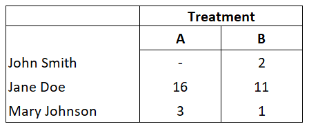

This table shows that treatment A and B are actually values and the variable is “treatment”. In other words, the column headers include values (A and B) as well as a variable name. In a tidy dataset, the values, A and B are in a cell. To change Table 5.1 in a tidy table, you need to add these values in a column:

Table 5.5: Illustration: A tidy version of the Treatment dataset.

|  | Treatment | Result |
| --- | --- | --- |
| John Smith | A | - |
| Jane Doe | A | 16 |
| Mary Johnson | A | 3 |
| John Smith | B | 2 |
| Jane Doe | B | 11 |
| Mary Johnson | B | 1 |

There are various ways in which a dataset can be “untidy”. As a matter of fact, there is only one way to store data in a tidy way but there are, theoretically, an unlimited number of ways to do so in an untidy way. In general, Wickham (2014) , lists 5 ways that datasets are untidy

1. column headers are values, not variable names
2. multiple variables are stored in one column
3. variables are stored in both rows and columns
4. multiple types of observational units are stored in the same table
5. a single observational unit is stored in multiple tables

In addition to these 5, sometime the cells contain two values.

Note the we already met the first: the column headings in Table 5.1 included values, A and B. A dataset can be untidy because it combines more than one of these ways to be “untidy”. In that case, moving from a untidy dataset to a tidy dataset will include multiple steps.

### 5.2.2 Column headers are values, not variable names

Often data is stored where column headers or column names are values. Consider Table 5.6 which includes an imaginary distribution of study efficiency across programs. The observational units here are the programs: Business administration, Law, Theology, … . The column headers show study efficiency categories: less than 25%, 25% or more but less than 50%, … . The cells show the number of students in each of the study-efficiency categories. This format is easy to read. However, it is not a tidy format. The column headers are values of a variable. In this case, this variable is “study_efficiency”. This variable is not included among the column names. In other words, you would have to add a title or add a note below the table to make sure that this is a table that others can interpret.

Table 5.6: Illustration: Column headers are values. Data refers to an imaginary distribution of study efficiency across programs

| degree | <25% | [25-50%[ | [25-75%[ | [75-99%[ | 100% |
| --- | --- | --- | --- | --- | --- |
| Business administrations | 25 | 75 | 102 | 178 | 75 |
| Law | 60 | 84 | 189 | 175 | 56 |
| Theology | 5 | 26 | 53 | 57 | 54 |
| Engineering | 75 | 79 | 68 | 185 | 152 |
| History | 22 | 23 | 18 | 89 | 12 |
| Languages | 17 | 14 | 18 | 69 | 1 |

The data in Table 5.6 are in so called wide format: variables are included in the columns. In this case, tidying the data includes the step of turning the wide format into a long format. In a long format, the values in the column header (here study-efficiency) are moved from the column header and used as values for a variable. The process includes the creation of a new column: “study_efficiency”. This variable records various categories in the column headers of Table 5.6. The result of this process produces dataset like Table 5.7 (this table shows only the first lines of a full long version):

Table 5.7: Illustration: Tidy data for “Column headers are values”. The table shows the first 11 rows of the long format of this dataset

| degree | study_efficiency | number_of_students |
| --- | --- | --- |
| Business administration | <25% | 25 |
| Business administration | [25-50%[ | 75 |
| Business administration | [50-75%[ | 102 |
| Business administration | [75-99%[ | 178 |
| Business administration | 100% | 75 |
| Law | <25% | 60 |
| Law | [25-50%[ | 84 |
| Law | [50-75%[ | 189 |
| Law | [75-99%[ | 175 |
| Law | 100% | 56 |
| Theology | <25% | 5 |

Note that the the table now includes a column which shows what the values <25%, … represent: study-efficiency. Changing the format from wide to long involves lengthening the dataset. In Table 5.7 there are more rows compared to Table 5.6, while the number of columns fell from 6 into 3 as 5 columns became 2.

Wide format is often used to store data. In Table 5.6, the values in the column names referred to study-efficiency categories. Other values that often show up in column headers are e.g. years as in Table 5.8. In this table, the data for 3 firms (e.g. market capitalization) is shown per year.

Table 5.8: Illustration: Wide format with years. Data refers to an imaginary table with market capitalization.

| firm | 2020 | 2021 | 2022 | 2023 | 2024 |
| --- | --- | --- | --- | --- | --- |
| A | 1236 | 1366 | 1455 | 1554 | 1689 |
| B | 201 | 204 | 215 | 325 | 410 |
| C | 12598 | 12698 | 12359 | 11985 | 11453 |

Note that here too, there is not an easy way to figure out what the values represent unless the title of the table, or a note below the table adds a description. Although here 2020, 2021, … have a natural interpretation, it is based on a guess that “2020” is a year and not e.g. the number of employees. In other words, this interpretation could be wrong. In a tidy dataset, you avoid these types of misinterpretation by adding a variable “year” whose values now include 2020, 2021, … .

Why are wide formats so popular? A wide format such as the one in Table 5.8, is often used as it is easy to compare values for a given year across firms or, for a given firm, across years, months or quarters. However, as the table increases, in number of years or in number of firms or both, a quick visual scan of the data become increasingly hard. With 500 firms (e.g. SP500), or with monthly data covering various years, a quick visual scan is impossible. In addition to the easy to visually scan for small tables, a wide format is often easy to input data. If your dataset includes a value per quarter, updating a table is as easy as adding a column. Likewise, if your dataset include the dates and times of the various stages of a delivery (ordered, order picked, goods arrived in warehouse, picked up by shipping agent, delivered), a wide format is convenient: you add the times in the relevant column in a sheet.

However, say you want to visualize Table 5.8 with the year on the horizontal axis and show the values per firm in a linegraph with the values on the vertical axis. In that case, you would need to select the column names as the values for the horizontal axis. Here, you can see that your column headers are values and not variables: on the horizontal (or vertical) axis of a plot, you add the values of the variable, not the variable names (or column names) as such. In a tidy dataset, as all columns are variables, you add the values, not the column names or variables to the axis of a plot. As another example, suppose you want to add the difference in market capitalization from one year to the other. In Table 5.8, you would need to add 4 columns, one for every year starting 2021 and probably use column names such as “2021-2020”, “2022-2021”. In other words, you are adding the “difference” in values for the year as a header. In a tidy dataset, that change in value would take one column: “difference” and you would calculate that difference as the difference in values, e.g. the difference between two rows.

Table 5.9: Illustration: Long format for Table 5.8

[output not shown]

How does the long format solve e.g. the issues with the axis in a plot. First note that you now have two variables, “year” for the horizontal axis and “market_cap” for the vertical axis. Here, we also have three values for the observational units. These values can now be used to draw 3 lines and add a visual way to differentiate between the three firms (e.g. a different color). In other words, the code now reads as: for every value for year in “year”, show the market capitalization in “market_cap” and do so for every firm in “firm” and select a different color for every firm in “firm”. Calculating a change in the market capitalization from one year to the other adds one column to the data. The calculation is straightforward: for every firm, calculate the difference between the value an its lagged values.

### 5.2.3 Multiple variables stored in one column

A column can store multiple variables. Let’s take a look at the example in Table 5.10. Here, you have an imaginary dataset with the number of students across nationality groups (EEA, non-EEA) and age group (18-19 and 20-21) in various programs. Here, the column names refer to two variables: nationality and age. To see this, it wouldn’t be hard to split this table in two parts.

Table 5.10: Illustration: Multiple variables stored in one column. Data refers to an imaginary distribution of students across nationalities (EEA - non-EEA) and ages (18-19 years and 20-21 years). Note that this table could e.g. include another row with merged cells above age for nationality.

| program | eea_18-19 | eea_20-21 | noneea_18-19 | noneea_20-21 |
| --- | --- | --- | --- | --- |
| Business administration | 189 | 71 | 258 | 236 |
| Law | 256 | 114 | 78 | 102 |

The first table would include the age groups in a wide format:

Table 5.11: Illustration: Split of Table 5.10 according to age.

| program | 18-19 | 20-21 |
| --- | --- | --- |
| Business administration | 447 | 307 |
| Law | 334 | 216 |

While the second table shows the nationalities, also in a wide format:

Table 5.12: Illustration: Split of Table 5.10 according to nationality.

| program | eea | noneea |
| --- | --- | --- |
| Business administration | 260 | 494 |
| Law | 370 | 180 |

Both tables Table 5.11 and Table 5.12 show that the columns in Table 5.10 include two variables. Splitting the latter in two separate tables, shows two tables in wide format. Note that every table here implies a loss of data. In Table 5.11, you loose the nationality; in Table 5.12, you loose the age.

Returning to Table 5.10, why is this table a problem in terms of data analysis? Suppose you want to calculate the share to non-EEA students in the total. That is not something which is easily done in that table. First you need to sum the values in all four columns. This gives you the total number of students in these programs. Second, you need to sum the fourth and fifth column. Given these two results, you can now calculate the share. The same holds for the share per age group. This calculation too would require multiple steps: calculate the total, sum columns 2 and 4 or 3 and 5 and finally, calculate the share.

To create a tidy format, two things must happen. First, the table layout must change from wide into long format. Second, names such as “eea_18-19” have to be split in two parts: “eea” and “18-19”. The first part, “eea” can then be used as a value in a variable “nationality”; the second as a value in a variable “age”. The final table will look like Table 5.13:

Table 5.13: Illustration: Tidy data for “Multiple variables stored in one column”.

| Program | nationality | age | number_of_students |
| --- | --- | --- | --- |
| Business administration | eea | 18-19 | 189 |
| Business administration | eea | 20-21 | 71 |
| Business administration | non-eea | 18-19 | 258 |
| Business administration | non-eea | 20-21 | 236 |
| Law | eea | 18-19 | 256 |
| Law | eea | 20-21 | 114 |
| Law | non-eea | 18-19 | 78 |
| Law | non-eea | 20-11 | 102 |

Here, the categories are straightforward and splitting “eea_18-19” or “noneea_20-21” isn’t all that hard if you know how to look for patterns in a character variable: the first part is a series of characters, the second includes 2 digits, a minus sign and 2 digits and both parts are separated by an underscore. However, it is not uncommon that these variables stored in a column include more than two and are less easy to separate. Doing so often requires using regular expressions to split the characters into their values.

### 5.2.4 Variables stored in both rows and columns

To illustrate this case, consider Table 5.14. Here, we have a table with imaginary data on train delays across two routes: Brussels - Antwerp and Brussels - Leuven. The first column shows these routes. The second column refers to the year and the third to the week of the year. The fourth column has two values: min and max. The column ’time” shows the minimum (if in the row where delay has minimum) and maximum (if in the row where delay has maximum) delay in minutes for that week.

Table 5.14: Illustration: Variables are stored in columns and rows. Data refers to an imaginary dataset recording minimum and maximum delay in minutes for trains on a given given route per week.

| route | year | week | delay | time |
| --- | --- | --- | --- | --- |
| bxl-ant | 2025 | 2 | min | 10 |
| bxl-ant | 2025 | 2 | max | 89 |
| bxl-leu | 2025 | 2 | min | 1 |
| bxl-leu | 2025 | 2 | max | 193 |

On the Brussels - Antwerp route, the minimum delay in week 2 of 2025 was 10 minutes while the maximum delay was 89 minutes. Here the problem is in the column “delay” in Table 5.14 because it actually includes variables: min and max. In other words, the column stores variables in its rows. Other variables are in the columns. For instance, time or week are variables (they measure time and a delay). In other words, variables are both in rows (min/max) as well as in columns (e.g. time).

To tidy the dataset, “min” and “max” must become columns. In other words, the column “delay” should be removed and two columns “min” and “max” should be added. The column “min” should include all the values that are now included in the rows where “delay” includes min; the column “max” should include all the values that are now included in the rows where “delay” includes max. As the values for the variable “time” are copies into the “min” and “max” columns, this column can be removed from the tidy dataset. Technically, you can split the table in two parts: one that includes only the row that show the minimum delay and one that includes only the rows that show maximum delay. Changing the name of the column from “delay” into “min” for the first and “max” for the second and merging both into a single table creates the tidy version of this dataset. This tidy dataset will look like

Illustration: The tidy version of Table 5.14.

| route | year | week | min | max |
| --- | --- | --- | --- | --- |
| bxl-ant | 2025 | 2 | 10 | 89 |
| bxl-leu | 2025 | 2 | 1 | 193 |

The problem with variables stored in both rows and columns is often associated with another issue: some column headers are values, not variable names. To illustrate this problem, consider Table 5.15. This table replaces the column time with 7 columns, one for each day of the week. Doing so, the values in column “mon” to “sun” show the minimum delay on that day (in the row where the column delay has “min”) and the maximum delay that day (in the row where the column delay has “max’). In other words, on the Brussels - Antwerp route, all trains were delayed in week 2, except for those riding on Thursday and Saturday (where the minimum delay was 0). On monday, they are all delayed a minimum of 10 minutes while the maximum delay that day was 89 minutes.

Table 5.15: Illustration: Variables are stored in columns and rows. Data refers to an imaginary dataset recording minimum and maximum delay in minutes for trains on a given given route per day.

| route | year | week | delay | mon | tue | wed | thu | fri | sat | sun |
| --- | --- | --- | --- | --- | --- | --- | --- | --- | --- | --- |
| bxl-ant | 2025 | 2 | min | 10 | 8 | 5 | 0 | 1 | 0 | 1 |
| bxl-ant | 2025 | 2 | max | 89 | 10 | 18 | 24 | 36 | 5 | 9 |
| bxl-leu | 2025 | 2 | min | 1 | 9 | 5 | 4 | 2 | 8 | 1 |
| bxl-leu | 2025 | 2 | max | 18 | 29 | 16 | 15 | 89 | 150 | 193 |

In Table 5.15, we have the same issues as in Table 5.14: the column “delay” includes variables: minimum and maximum delay. In addition, the column headers “mon”, “tue”, “wed”, “thu”, “fri”, “sat” and “sun” are values, not variables. Recall that there are many way that you can handle date/time variables in R. Here, using the number of the week (2), the year (2025) and the day (mon, tue, …) allows to determine the exact date: the first day of week 2 in 2025 was 2025-01-06 (using monday as the first day of the week and using ISOweeks).

In this this case, the “column headers are values, not variables names” is the first issue we need to solve. Doing so, reduces the problem to the same problem as we had in Table 5.14. The column “delay” includes variable names. Solving that issue returns the tidy dataset in Table 5.16.

Table 5.16: Illustration: Tidy data for “Variables are stored in columns and rows’.

| route | day | min | max |
| --- | --- | --- | --- |
| blx-ant | 2025-01-06 | 10 | 89 |
| blx-ant | 2025-01-07 | 8 | 10 |
| blx-ant | 2025-01-08 | 5 | 18 |
| blx-ant | 2025-01-09 | 0 | 24 |
| blx-ant | 2025-01-10 | 1 | 36 |
| blx-ant | 2025-01-11 | 0 | 5 |
| blx-ant | 2025-01-12 | 1 | 9 |
| blx-leu | 2025-01-06 | 1 | 18 |
| blx-leu | 2025-01-07 | 9 | 29 |
| blx-leu | 2025-01-08 | 5 | 16 |
| blx-leu | 2025-01-09 | 4 | 15 |
| blx-leu | 2025-01-10 | 2 | 89 |
| blx-leu | 2025-01-11 | 8 | 150 |
| blx-leu | 2025-01-12 | 1 | 193 |

### 5.2.5 Multiple types of observational units in the same table

We can use Table 5.15 to illustrate another problem: multiple types of observational units are in the same table. To see what this means, let’s look at Table 5.17. This table copies Table 5.15, but adds three variables: “type” for the type of the train, “dur” for the normal time the route takes for the specific type of train and “cap” the capacity of the train. Suppose the same type of train is always used on the same route. In other words, an M7 with capacity 400 is always used on the Brussels - Antwerp route and, using that train, the normal time for that route is 45 minutes. If that is the case, the data on type, dur, and cap will appear multiple times. In Table 5.17, you can see that the values “M7”, “45” and “400” always appear in the observations for bxl-ant. The same holds for bxl-leu, where you always see “M8”, “30” and “250”.

Table 5.17: Illustration: Multiple types in one table. Data refers to an imaginary dataset recording minimum and maximum delays in minutes for trains on a given given route per day. Data includes the type of the train, the normal time and the capacity of the train.

| route | year | week | type | dur | cap | delay | mon | tue | wed | thu | fri |
| --- | --- | --- | --- | --- | --- | --- | --- | --- | --- | --- | --- |
| bxl-ant | 2025 | 2 | M7 | 45 | 400 | min | 10 | 8 | 5 | 0 | 1 |
| bxl-ant | 2025 | 2 | M7 | 45 | 400 | max | 89 | 10 | 18 | 24 | 36 |
| bxl-leu | 2025 | 2 | M8 | 30 | 250 | min | 1 | 9 | 5 | 4 | 2 |
| bxl-leu | 2025 | 2 | M8 | 30 | 250 | max | 18 | 29 | 16 | 15 | 89 |

The problem here is that Table 5.17 mixes to observational units: the route (bxl-ant) and the train (M7, M8). Here, the data for the unit “train” refer to the type, the duration and the capacity. Technically, you can remove these from Table 5.17 and store them in a different table, e.g. Table 5.18.

Table 5.18: Illustration: Tidy data for “Multiple types in one table”. Table refers to the data per train. The other table would include all data as in the Illustration: Tidy data for “Variables stored in columns and rows”.

| route | type | dur | cap |
| --- | --- | --- | --- |
| bxl-ant | M7 | 45 | 400 |
| bxl-ant | M7 | 45 | 400 |
| bxl-leu | M8 | 30 | 250 |
| bxl-leu | M8 | 30 | 250 |

This problem might occur in datasets which include customer data. Suppose that you have a dataset with transactions: “who” bought “what”, “when”, “how” and what where the pricing conditions “price”, “discount”, … .. For the “who” part, you have a loyalty card which includes the name of the “who”, age, city where that person lives, … . Adding these personal items to the dataset with transactions creates a problem where multiple observational units are in the same dataset. In this case, the transactions and the customer.

### 5.2.6 A single observational unit is stored in multiple tables

The fifth issues arises often when datasets are regularly updated. Consider for instance, the data on the monthly consumer price index. This dataset includes, for every month and for a large set of items the percentage change in their price. Table 5.19 and Table 5.20 show two imaginary datasets with a very limited number of items in the CPI baskets.

Table 5.19: Illustrations: One type in multiple tables. Data refers to an imaginary dataset recording inflation data for specific items for one specific month (e.g. April).

| Item | inflation |
| --- | --- |
| food and drinks | 2.36% |
| restaurants and hotels | 9.48% |
| vegetables, fresh | -1.18% |
| vegetables, frozen | 0.18% |

Table 5.20: Illustrations: One type in multiple tables. Data refers to an imaginary dataset recording inflation data for specific items for one specific month (e.g. May)

| Item | inflation |
| --- | --- |
| food and drinks | 4.89% |
| restaurants and hotels | 1.48% |
| vegetables, fresh | 2.18% |
| vegetables, frozen | -1.22% |

Here, the problem arises because the first dataset, which refers to April, is published one month before the second, which is published in May. In other words, you have two datasets and need to merge these into one. In this case, the solution if usually straightforward: if the datasets include the same variables, all it takes is add them via `rbind()` after adding the month as a separate variable. The tidy dataset looks like Table 5.21.

Table 5.21: Illustration: Tidy data for “One type in multiple tables”.

| Item | Inflation | month | year |
| --- | --- | --- | --- |
| food and drinks | 2.36% | April | 2024 |
| restaurants and hotels | 9.48% | April | 2024 |
| vegetables, fresh | -1.18% | April | 2024 |
| vegetables, frozen | 0.18% | April | 2024 |
| food and drinks | 4.89% | may | 2024 |
| restaurants and hotels | 1.48% | may | 2024 |
| vegetables, fresh | 2.18% | may | 2024 |
| vegetables, frozen | -1.22% | may | 2024 |

In other cases, the data is stored in various datasets, for instance, a collection of datasets for firms stores data per firm in a separate file. Here too, the solution is straightforward. However, there is one extra complexity. If the individual tables don’t include the name of the firm, country or city, you might find them in the name of the file that stores the data. If that is the case, adding these datasets requires a couple of steps. First, read the file names and store them. Import each file as a data frame and add a column with the name of the firms, country or city. Merge the files using `rbind()`.

As long as the datasets don’t change (much), this is straightforward. However, if the datasets change over time, dealing with this issue can be very complex and by very challenging to create a nice tidy dataset.

### 5.2.7 Multiple values in one cell

Suppose you have a dataset that looks like the one in table Table 5.22. The variable GDP includes values that refer to the size of the economy in the local currency. Here, these values include two values: the size of the economy and the currency.

Table 5.22: Illustration: One cell holds multiple values. Date refer to an very rough approximation of GDP in national currencies.

| country | year | gdp |
| --- | --- | --- |
| United States | 2022 | usd 30338000 |
| Germany | 2022 | eur 5100000 |
| Japan | 2022 | yen 658500000 |

A tidy version of Table 5.22 splits the column GDP in two parts: the size of the economy in a variable “gdp” and the currency in a variable “currency”. Doing so results in the tidy dataset in Table 5.23.

| country | year | gdp | currency |
| --- | --- | --- | --- |
| United States | 2022 | 30338000 | usd |
| Germany | 2022 | 5100000 | eur |
| Japan | 2022 | 658500000 | yen |

Here, this last column can be used to add the value of the currency for the year in “year”. Doing so requires that you merge this dataset with a dataset on exchange rates, e.g. for the euro/dollar and euro/yen. Doing so would allow you to calculate GDP in a common currency.

## 5.3 The tidyverse

Wickham, Hadley. 2014. “Tidy Data.” *Journal of Statistical Software* 59 (10): 1–23. https://doi.org/10.18637/jss.v059.i10.